## Data and Methods: A Census of Comments in Agency Rulemaking

Through an iterative combination of automated search methods and hand-coding, I identify the elected official or organization that submitted each comment.

Figure @ref(fig:congress) shows the number of comments from members of Congress received during rulemaking by a sample of federal agencies. Oversight letters are frequently co-signed by multiple members from the Senate, House, or both chambers.

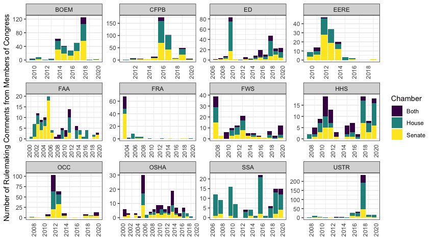

Number of Letters from Members of Congress Received During Rulemaking per Year

```r
knitr::include_graphics(here::here("figs", "comments-congress.png"))
```

I measure the dependent variables—legislator attention and support—in several ways. First, I count the number of times members of Congress engage the agency across rules and before, during, and after comment periods on rules where lobbying organizations did and did not go public. By engaging the agency, I mean that members of Congress raise a rule in personal correspondence or comments that members send to the agency. I then code each contact from the member of Congress and each coalition lobbying on the rule on the same three-point scale: are they asking for the rule to go further, be scaled back, or published as-is. This is similar to other hand-coding approaches to policy demands. Next, I use text analysis to compare the sentiment and rhetoric (phrases and word frequencies) used by legislators to the language used by each coalition.

## Preliminary findings

I find that more public pressure correlates with more congressional oversight. This includes comments from legislators both for and against proposed rules. For example, when the Department of the Treasury published draft rules implementing the Unlawful Internet Gambling Act of 2006, the proposal generated unusually high levels of public attention. As a result, two bipartisan groups of legislators submitted comments on the rule. One, led by the chair of the House Judiciary Subcommittee on Commercial and Administrative Law, raised concerns about the Department’s implementation of the Administrative Procedures Act. The other group of legislators, led by Senator Mike Pence, pushed back against interest-group opposition to the rule and urged the Department to go forward with the implementing rules. This case illustrates several broader trends that I observe. Members of Congress are more likely to engage in oversight when interest groups and the public pay more attention to an issue. When legislators do engage in rulemaking, they often engage on both sides of the issue, raising process or policy concerns that may push agencies in multiple directions.

### Models testing the relationship between mass engagement and oversight

There are several ways to test for a relationship between mass engagement and engagement by Members of Congress. The key explanatory variables of interest are the measures of mass engagement created in step 1 (how many and what types of comments). For simplicity, in the equations below, I only include measures related to the number of comments. Thus $\beta_0$ is the estimate for a rule with no public comments.

In Model 1, the dependent variable is the total number of comments from Members of Congress on the rule: *$Y$ = Total comments from Congress* $\sim$ zero-inflated negative binomial, with one observation per rule. Let $x$ be the the total number of public comments.

$$\begin{aligned}
Y \sim \beta_0 + \beta_1x\end{aligned}$$

In Model 2, the dependent variable is the number of comments from Members of Congress on the rule that support the coalition or organizations in the coalition: $Y_i$ = *Total comments from Congress supporting coalition $i$* $\sim$ negative binomial, with one observation per coalition per rule. Let $x_i$ be the total number of public comments supporting coalition $i$.

$$\begin{aligned}
Y_i \sim \beta_0 + \beta_1 x_i\end{aligned}$$

In Model 3, the dependent variable is the share of Congressional comments supporting the coalition: $Y_i$ = *Share of Members of Congress supporting coalition $i$* $\sim$ beta, with one observation per coalition per rule. Let $z_i$ be the *share* of public comments supporting coalition $i$.

$$\begin{aligned}
Y_i \sim \beta_0 + \beta_1 z_i\end{aligned}$$

In Model 4, the dependent variable is rhetorical similarity between comments of each coalition $i$ and each Members of Congress $j$: $Y_{ij}$ = *Text similarity score between legislator comment and coalition $i$ texts*, with one observation per legislator comment per coalition. Let $z_i$ be the share of public comments supporting coalition $i$.

$$\begin{aligned}
Y_{ij} ~ \sim \beta_0 + \beta_1 z_i\end{aligned}$$

#### Limitations.

One challenge will be controlling for rule salience, which may affect both public and legislator attention (indeed, both are endogenous to rule salience). Another challenge will be controlling for latent public opinion, which may usually, but not exclusively, be revealed to legislators through mass engagement.